# Introduction to Biostatistics

# 1 Learning objectives

## 1.1 Learning objectives

- Advanced plotting
  - Color, size, opacity
  - Annotations
  - Changing themes, axis labels, re-ordering categories
  - Complex and combined plots

# 2 Perception

## 2.1 Perception

- Data is encoded in graphics
  - How can we make it easier for people to understand?
  - What are humans good (and bad) at?

## 2.2 What are we good (and bad) at?

- Good: Comparing position and length
  - Scatterplots, bar plots
- Good: Color!
  - Use color to highlight, identify, group
  - Caveats: Colorblindness, contrast, accessibility
- Bad: Comparing areas, volume, curvature
  - Pie charts

# 3 Data

## 3.1 Data

```r
library(gapminder)
data(gapminder)
gap_2007 <- gapminder %>% filter(year == 2007)
head(gap_2007)
```

```
# A tibble: 6 × 6
  country     continent  year lifeExp      pop gdpPercap
  <fct>       <fct>     <int>   <dbl>    <int>     <dbl>
1 Afghanistan Asia       2007    43.8 31889923      975.
2 Albania     Europe     2007    76.4  3600523     5937.
3 Algeria     Africa     2007    72.3 33333216     6223.
4 Angola      Africa     2007    42.7 12420476     4797.
5 Argentina   Americas   2007    75.3 40301927    12779.
6 Australia   Oceania    2007    81.2 20434176    34435.
```

# 4 Colors

## 4.1 “color” and “fill”

- Some objects have a “`color`” attribute
  - This is the color for the whole object
- Some objects have both “`color`” and “`fill`” attributes
  - “`color`” is the outline color
  - “`fill`” is the “filled in” color

## 4.2 Built-in colors in R

- http://sape.inf.usi.ch/quick-reference/ggplot2/colour
- https://r-charts.com/colors/
- Type `colors()` in the Console for a list of all colors in R
  - Use the color’s name

## 4.3 Specific colors: Cedars-Sinai

- Red
  - RGB: 220, 30, 52
  - HEX: #dc1e34
- Grey
  - RGB: 118, 119, 122
  - HEX: #76777a

```r
CS_red <- "#dc1e34"
CS_grey <- "#76777a"
```

## 4.4 Create a color palette

- Color-blind friendly colors from https://jfly.uni-koeln.de/color/

```r
color_blind_friendly <- c("#E69F00", "#000000", "#56B4E9", "#009E73",
                          "#F0E442", "#0072B2", "#D55E00", "#CC79A7")
```

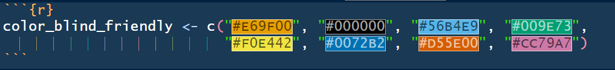

- [Check your plot for color-blind-friendliness](https://www.color-blindness.com/coblis-color-blindness-simulator/)

## 4.5 Change colors manually

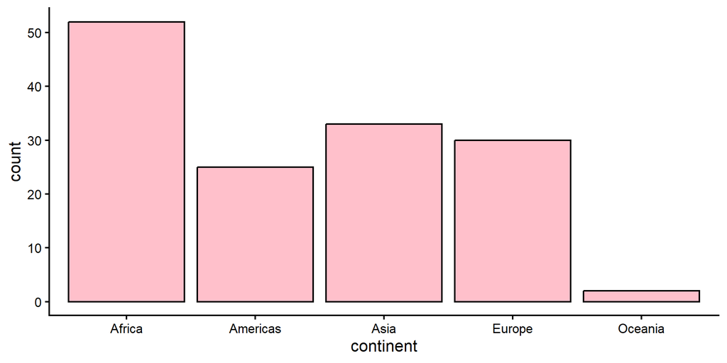

```r
ggplot(data = gap_2007,
       aes(x = continent)) +
  geom_bar(color = "black",
           fill = "pink")
```

## 4.6 Change colors manually

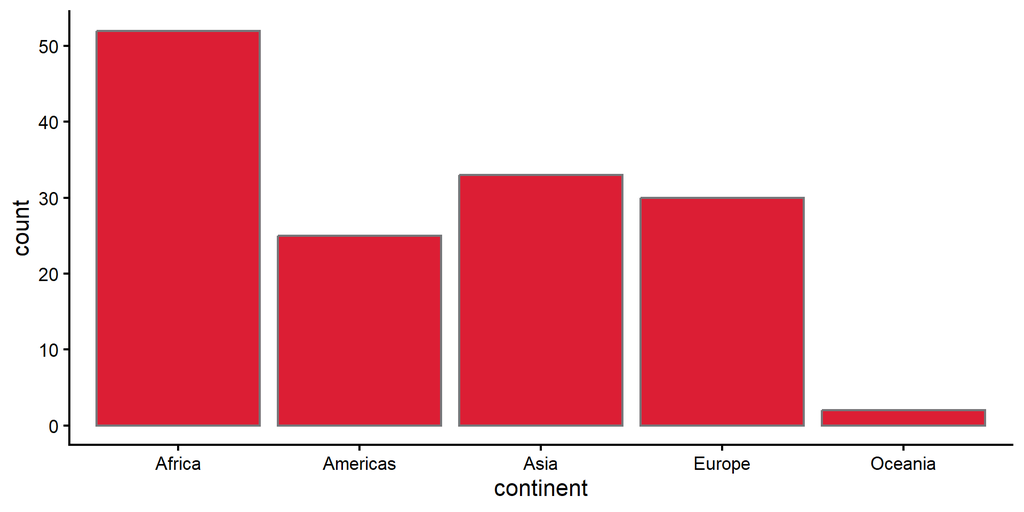

```r
ggplot(data = gap_2007,
       aes(x = continent)) +
  geom_bar(color = CS_grey,
           fill = CS_red)
```

## 4.7 Colors based on a variable

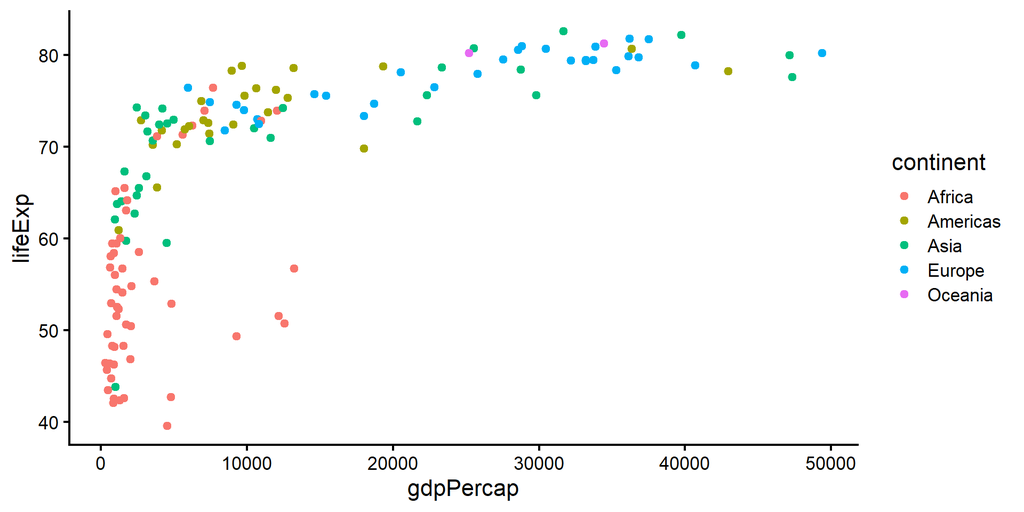

```r
ggplot(data = gap_2007,
       aes(x = gdpPercap,
           y = lifeExp,
           color = continent)) +
  geom_point()
```

## 4.8 Colors based on a variable (CB)

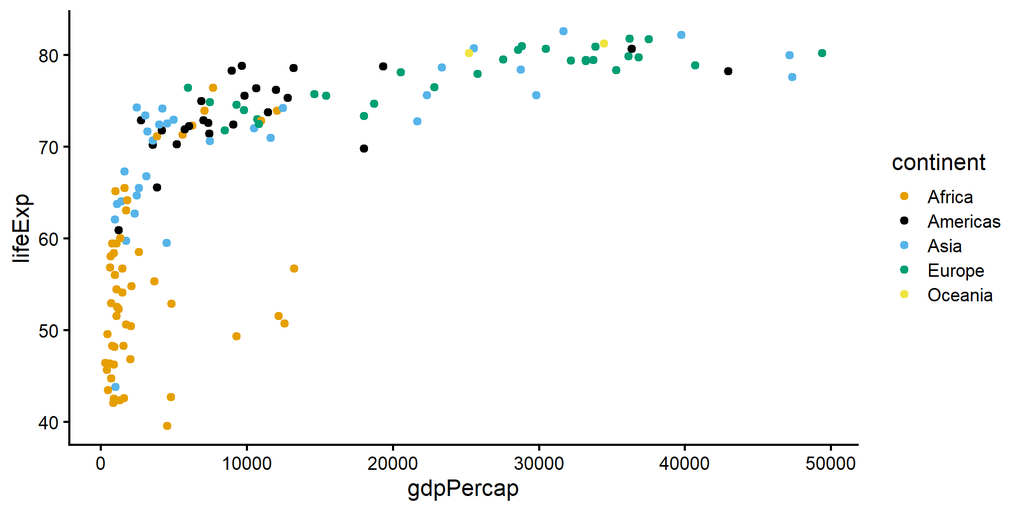

```r
ggplot(data = gap_2007,
       aes(x = gdpPercap,
           y = lifeExp,
           color = continent)) +
  geom_point() +
  scale_color_manual(values = color_blind_friendly)
```

- `scale_color_manual()` for `color`
- `scale_fill_manual()` for `fill`

# 5 Size and opacity

## 5.1 Change line width

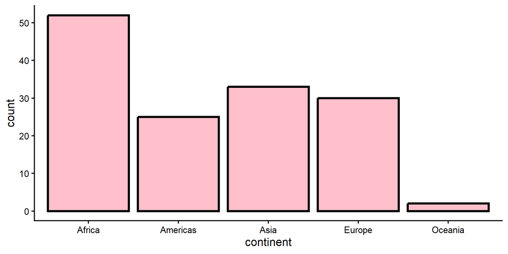

```r
ggplot(data = gap_2007,
       aes(x = continent)) +
  geom_bar(color = "black",
           fill = "pink",
           linewidth = 1.5)
```

## 5.2 Change point size

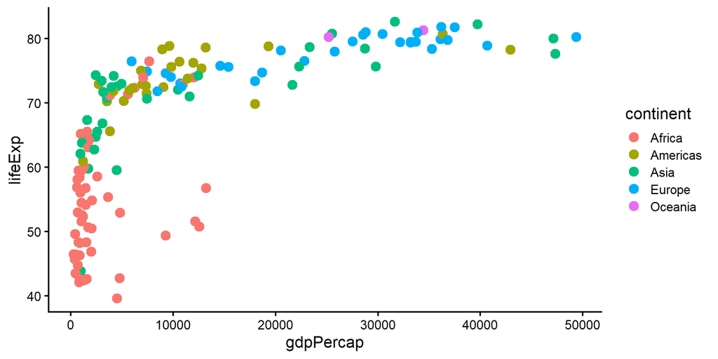

```r
ggplot(data = gap_2007,
       aes(x = gdpPercap,
           y = lifeExp,
           color = continent)) +
  geom_point(size = 4)
```

## 5.3 Change opacity of points

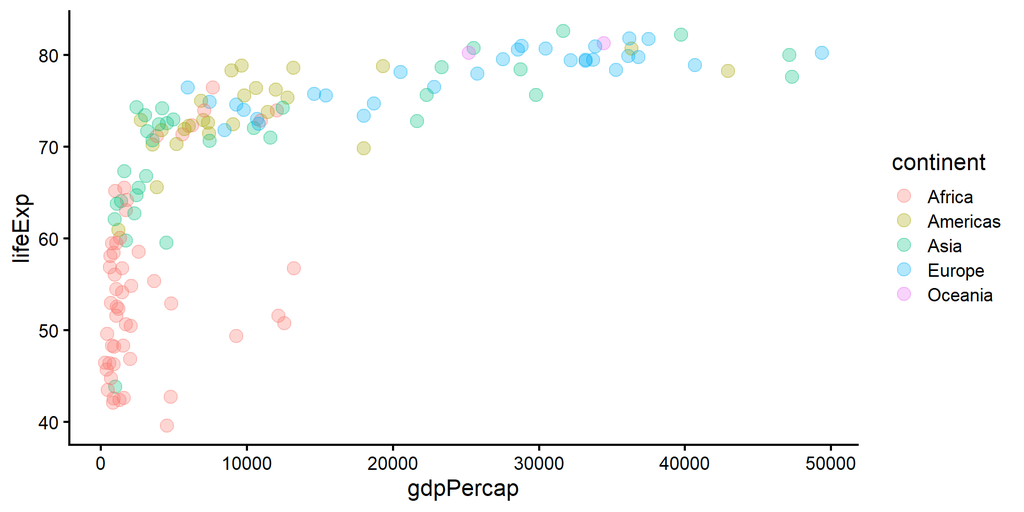

```r
ggplot(data = gap_2007,
       aes(x = gdpPercap,
           y = lifeExp,
           color = continent)) +
  geom_point(size = 4, alpha = 0.3)
```

# 6 Annotations

## 6.1 `annotate()` layer

- General function to add different **types** of annotations
  - `"text"`
  - `"rect"`
  - `"segment"`
  - `"pointrange"`
- Also specify location of the annotation
  - x, y
  - xmin, ymin, xmax, ymax, xend, yend

## 6.2 Add some text

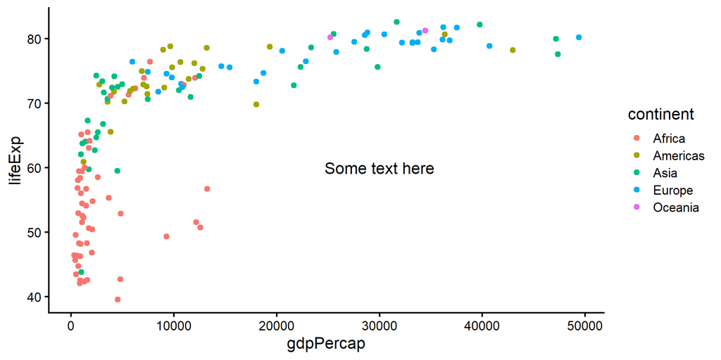

```r
ggplot(data = gap_2007,
       aes(x = gdpPercap,
           y = lifeExp,
           color = continent)) +
  geom_point() +
  annotate("text",
           x = 30000, y = 60,
           label = "Some text here")
```

## 6.3 Add a rectangle

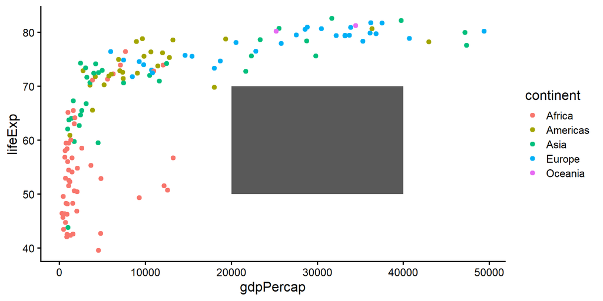

```r
ggplot(data = gap_2007,
       aes(x = gdpPercap,
           y = lifeExp,
           color = continent)) +
  geom_point() +
  annotate("rect",
           xmin = 20000, xmax = 40000,
           ymin = 50, ymax = 70)
```

## 6.4 Useful annotation

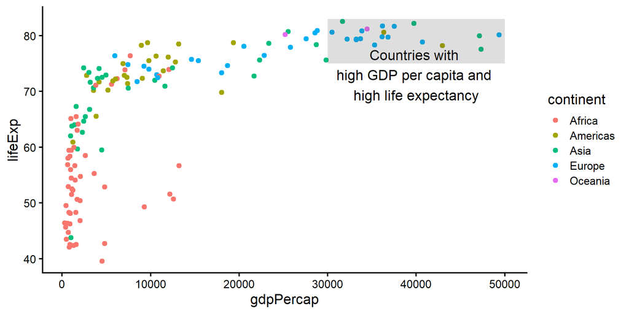

```r
ggplot(data = gap_2007,
       aes(x = gdpPercap,
           y = lifeExp,
           color = continent)) +
  geom_point() +
  annotate("text",
           x = 40000, y = 73,
           label = "Countries with \nhigh GDP per capita and \nhigh life expectancy") +
  annotate("rect",
           xmin = 30000, xmax = 50000,
           ymin = 75, ymax = 83,
           alpha = 0.2)
```

# 7 Labels and axes

## 7.1 `labs()` layer

- **All the labels** in the plot
  - Title, subtitle, caption
  - Legend title
  - X and Y axis labels
- Still supports older versions: `xlab()`, `ylab()`, `ggtitle()`

## 7.2 Title and subtitle

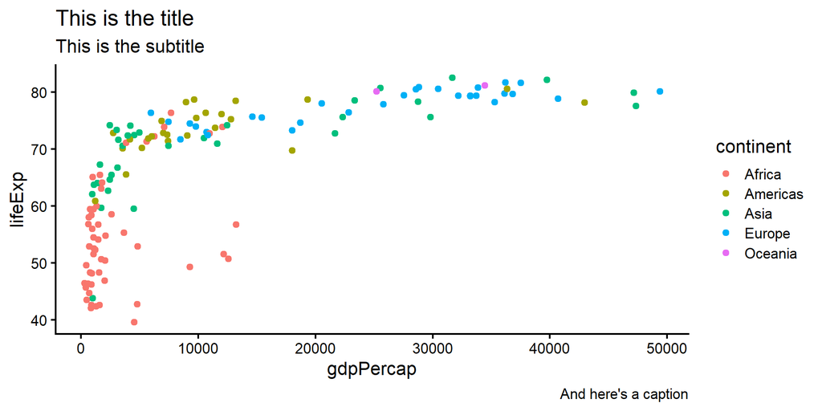

```r
ggplot(data = gap_2007,
       aes(x = gdpPercap,
           y = lifeExp,
           color = continent)) +
  geom_point() +
  labs(title = "This is the title",
       subtitle = "This is the subtitle",
       caption = "And here's a caption")
```

## 7.3 Title and subtitle

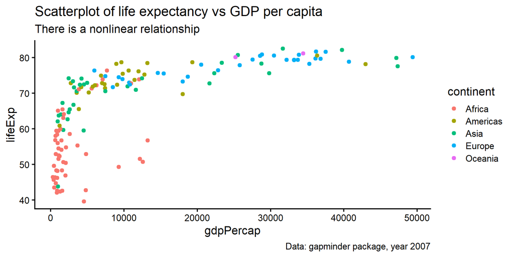

```r
ggplot(data = gap_2007,
       aes(x = gdpPercap,
           y = lifeExp,
           color = continent)) +
  geom_point() +
  labs(title = "Scatterplot of life expectancy vs GDP per capita",
       subtitle = "There is a nonlinear relationship",
       caption = "Data: gapminder package, year 2007")
```

## 7.4 Axis and legend labels

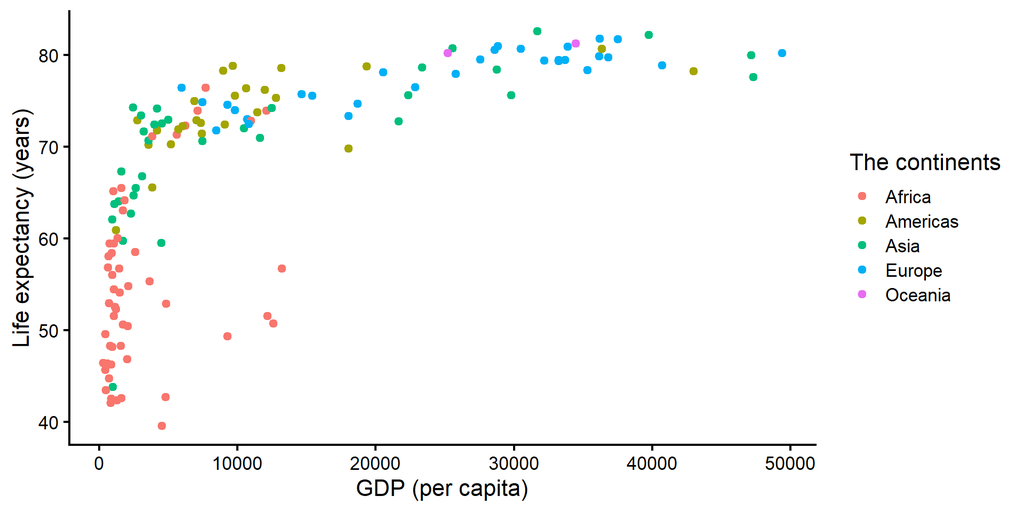

```r
ggplot(data = gap_2007,
       aes(x = gdpPercap,
           y = lifeExp,
           color = continent)) +
  geom_point() +
  labs(x = "GDP (per capita)",
       y = "Life expectancy (years)",
       color = "The continents")
```

# 8 Changes to theme

## 8.1 Themes

- Built-in themes: `theme_classic()`, `theme_grey()`, etc.
- Packages to change theme
  - **ggthemes**: 538, WSJ, Economist
  - **bbplot**: BBC
- Make your own theme: Branding
- Change theme for whole document
  - e.g., `theme_set(theme_classic())` in setup chunk

## 8.2 Theme elements

- If you know the name of the part you want to change, you can change it
  - https://ggplot2.tidyverse.org/reference/theme.html

## 8.4 Limits, ticks, etc.

- Adjust the axis limits, labels, or ticks for **continuous** variable
  - `scale_x_continuous()` and `scale_y_continuous()`
- Adjust the axis limits, labels, or ticks for **discrete** variable
  - `scale_x_discrete()` and `scale_y_discrete()`
- Adjust just the limits
  - `xlim()` and `ylim()`

# 9 Adjust variables on the fly

## 9.1 Default order for factors

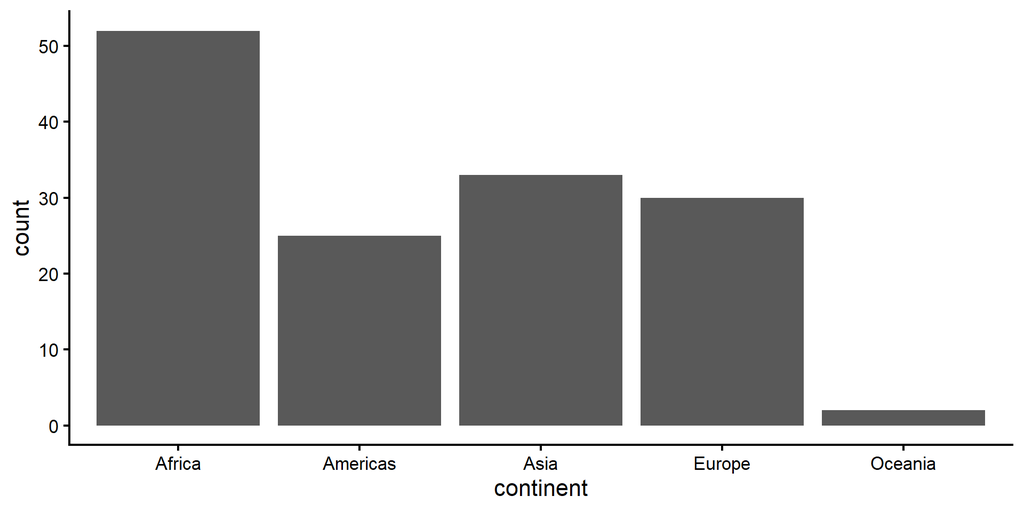

```r
ggplot(data = gap_2007,
       aes(x = continent)) +
  geom_bar()
```

## 9.2 Re-order factor levels in the plot

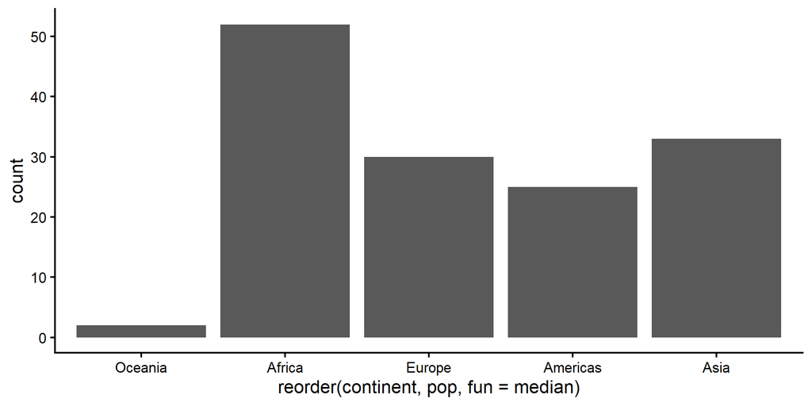

```r
ggplot(data = gap_2007,
       aes(x = reorder(continent,
                       pop,
                       fun = median))) +
  geom_bar()
```

## 9.3 Re-order factor levels in the plot

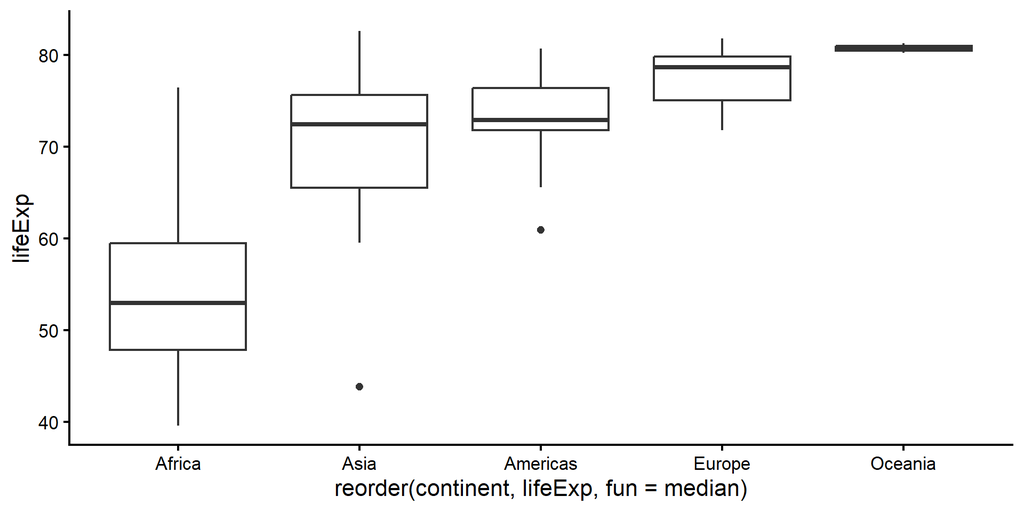

```r
ggplot(data = gap_2007,
       aes(x = reorder(continent,
                       lifeExp,
                       fun = median),
           y = lifeExp)) +
  geom_boxplot()
```

## 9.4 Re-order and other things

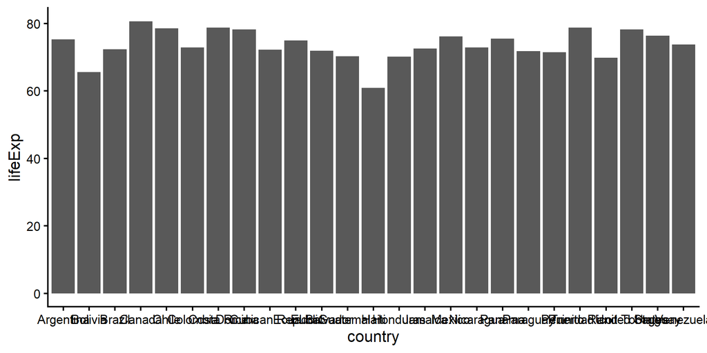

```r
gap_2007_americas <- gap_2007 %>%
  filter(continent == "Americas")
ggplot(data = gap_2007_americas,
       aes(x = country,
           y = lifeExp)) +
  geom_col()
```

## 9.5 Re-order and other things

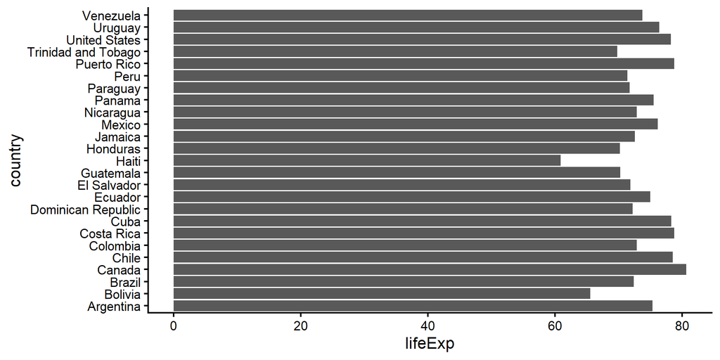

```r
ggplot(data = gap_2007_americas,
       aes(x = country,
           y = lifeExp)) +
  geom_col() +
  coord_flip()
```

## 9.6 Re-order and other things

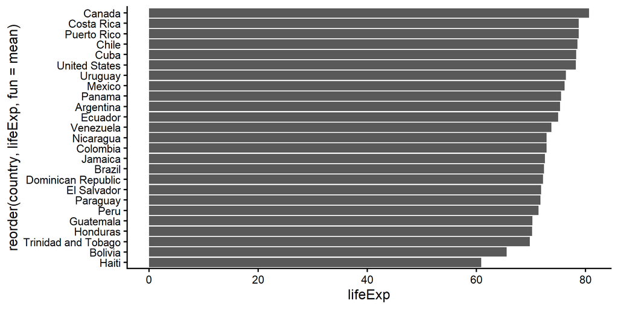

```r
ggplot(data = gap_2007_americas,
       aes(x = reorder(country,
                       lifeExp,
                       fun = mean),
           y = lifeExp)) +
  geom_col() +
  coord_flip()
```

## 9.7 Alternative: Rotate axis text

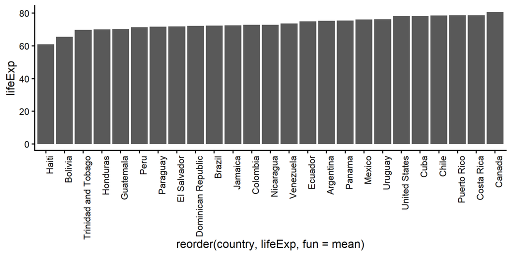

```r
ggplot(data = gap_2007_americas,
       aes(x = reorder(country,
                       lifeExp,
                       fun = mean),
           y = lifeExp)) +
  geom_col() +
  theme(axis.text.x = element_text(angle = 90,
                                   hjust=1))
```

# 10 Complex / combined plots

## 10.1 Index plot (Manhattan plot)

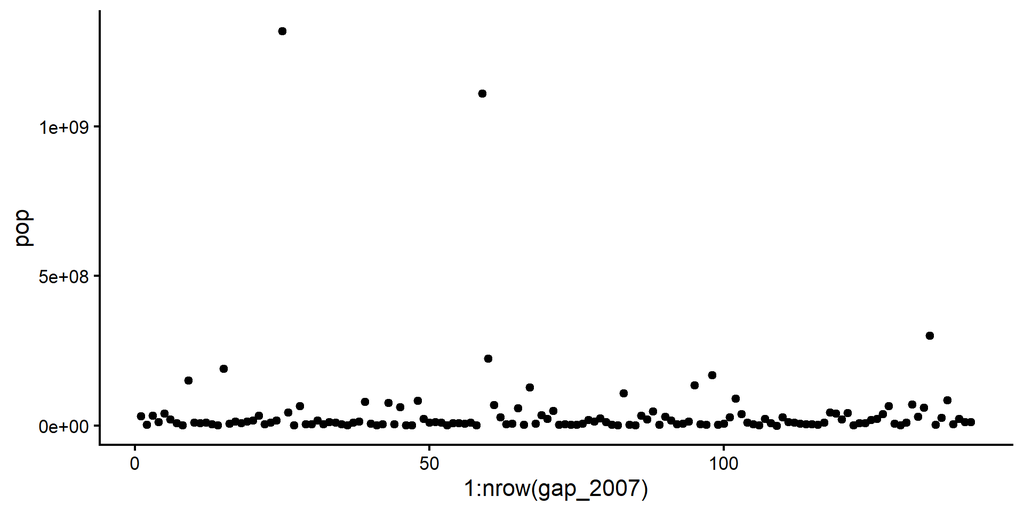

```r
ggplot(data = gap_2007,
       aes(x = 1:nrow(gap_2007),
           y = pop)) +
  geom_point()
```

## 10.2 Index plot with labels

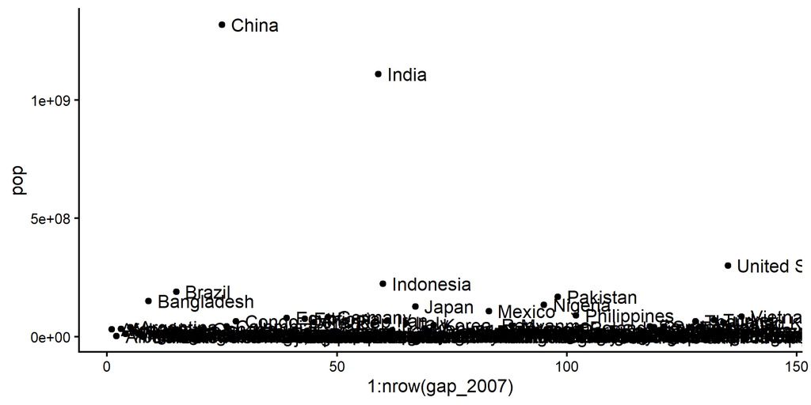

```r
ggplot(data = gap_2007,
       aes(x = 1:nrow(gap_2007),
           y = pop)) +
  geom_point() +
  geom_text(aes(label=as.character(country)),
            hjust = 0, nudge_x = 2)
```

## 10.3 Index plot with labels

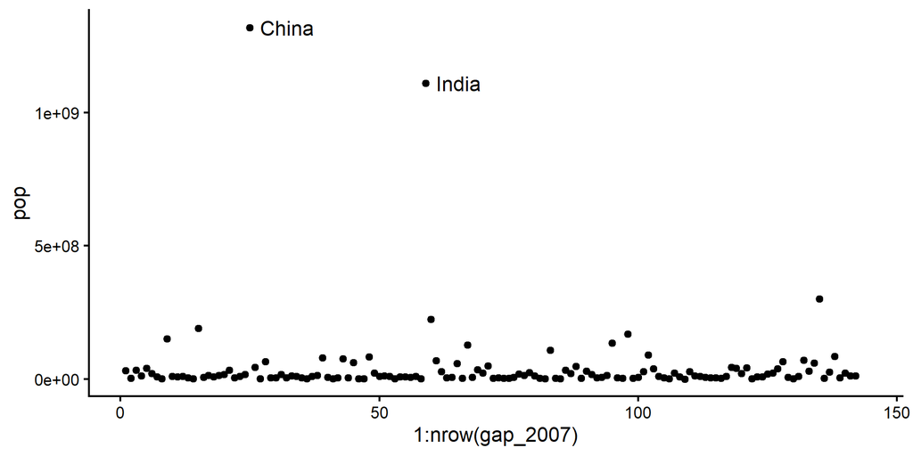

```r
ggplot(data = gap_2007,
       aes(x = 1:nrow(gap_2007),
           y = pop)) +
  geom_point() +
  geom_text(aes(label=ifelse((pop > 500000000),
                             as.character(country),
                             '')),
            hjust = 0, nudge_x = 2)
```

## 10.4 Bells and whistles version

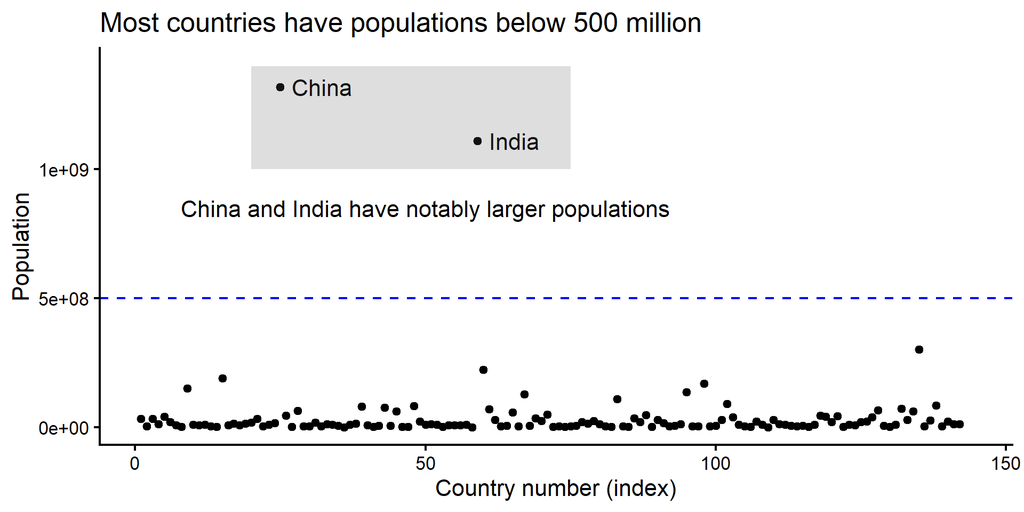

```r
ggplot(data = gap_2007,
       aes(x = 1:nrow(gap_2007),
           y = pop)) +
  geom_point() +
  geom_text(aes(label=ifelse((pop > 500000000),
                             as.character(country),
                             '')),
            hjust = 0, nudge_x = 2) +
  geom_hline(yintercept = 500000000,
             color = "blue",
             linetype = "dashed") +
  annotate("text",
           x = 50, y = 850000000,
           label = "China and India have notably larger populations") +
  annotate("rect",
           xmin = 20, xmax = 75,
           ymin = 1000000000, ymax = 1400000000,
           alpha = 0.2) +
  labs(title = "Most countries have populations below 500 million",
       x = "Country number (index)",
       y = "Population")
```

## 10.5 Add rugs to a scatterplot

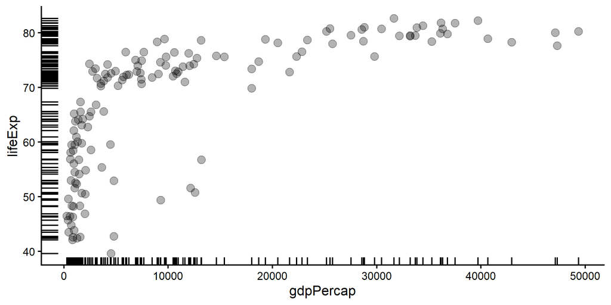

```r
ggplot(data = gap_2007,
       aes(x = gdpPercap,
           y = lifeExp)) +
  geom_point(size = 4, alpha = 0.3) +
  geom_rug()
```

## 10.6 Add rugs to a scatterplot

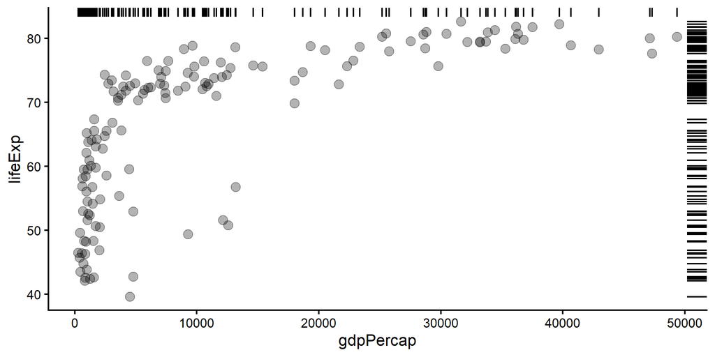

```r
ggplot(data = gap_2007,
       aes(x = gdpPercap,
           y = lifeExp)) +
  geom_point(size = 4, alpha = 0.3) +
  geom_rug(sides = "tr")
```

## 10.7 Lollipop plot

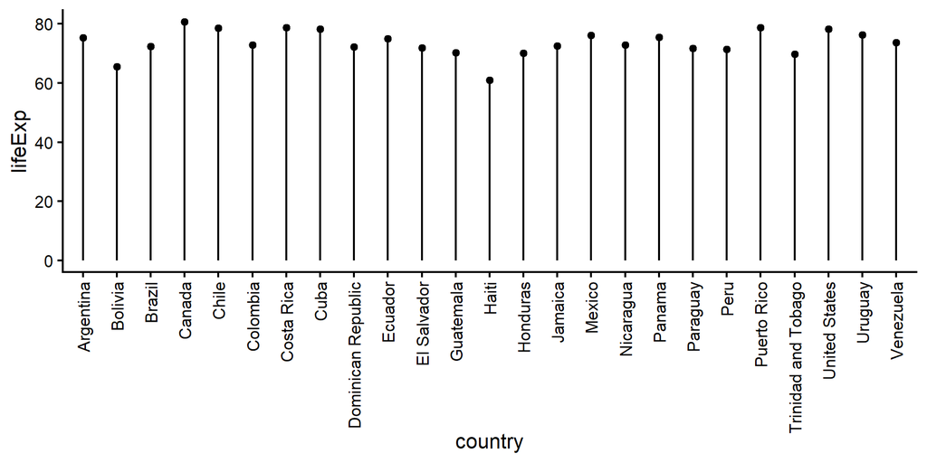

```r
ggplot(data = gap_2007_americas,
       aes(x = country,
           y = lifeExp)) +
  theme(axis.text.x = element_text(angle = 90,
                                   hjust=1,
                                   vjust = 0.5)) +
  geom_point() +
  geom_segment(aes(x = country,
                   xend = country,
                   y = 0,
                   yend = lifeExp))
```

## 10.8 Lollipop plot

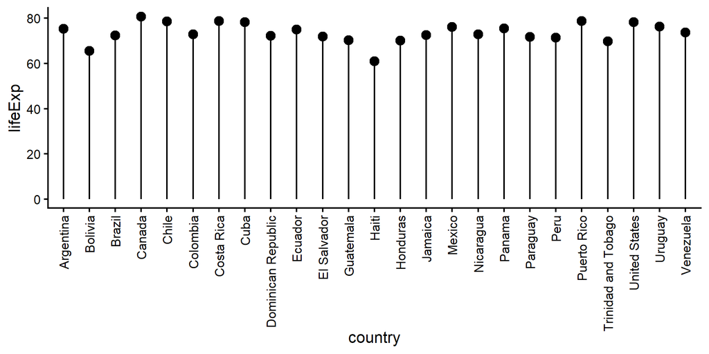

```r
ggplot(data = gap_2007_americas,
       aes(x = country,
           y = lifeExp)) +
  theme(axis.text.x = element_text(angle = 90,
                                   hjust=1,
                                   vjust = 0.5)) +
  geom_point(size = 4) +
  geom_segment(aes(x = country,
                   xend = country,
                   y = 0,
                   yend = lifeExp))
```

## 10.9 Raincloud plot

- [Allen, M., Poggiali, D., Whitaker, K., Marshall, T. R., van Langen, J., & Kievit, R. A. (2019). Raincloud plots: a multi-platform tool for robust data visualization. Wellcome open research, 4.](https://www.ncbi.nlm.nih.gov/pmc/articles/PMC6480976/)
- Install **ggrain** package
  - Or use custom scripts in the article
- Dot plot + box plot + (half) violin plot

## 10.10 Raincloud plot

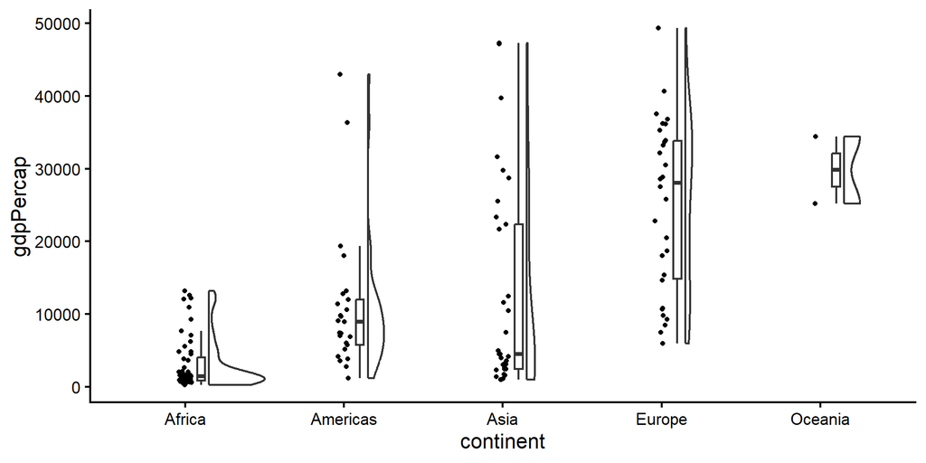

```r
library(ggrain)
ggplot(gap_2007,
       aes(x = continent,
           y = gdpPercap)) +
  geom_rain()
```